# Top Spotify Tracks of 2017

James Le

Updated: 2018-05-20

# Introduction

In this notebook, I’ll take a look at the audio features of the tracks in **Spotify’s Top Songs of 2017** playlist and try to highlight the common patterns behind the audio features of these songs. Specifically, I will find out what are the secret ingradients (Tempo, Keys, Names) to make a song popular.

# Data Preparation

First off, let’s import the data and get an idea of what I’m working with.

```r
library(readr)
library(plyr)
library(dplyr)
library(ggplot2)
library(tidyverse)
library(reshape)

audio_features <- read.csv('Spotify-Audio-Features.csv')
```

Let’s take a look at the summary of this dataset.

```r
head(audio_features)
```

|  | id | name | artists | danceability | energy | key | loudness | mode | speechiness | acousticness | instrumentalness | liveness | valence | tempo | duration_ms | time_signature |
| --- | --- | --- | --- | --- | --- | --- | --- | --- | --- | --- | --- | --- | --- | --- | --- | --- |
| 1 | 7qiZfU4dY1lWllzX7mPBI | Shape of You | Ed Sheeran | 0.825 | 0.652 | 1 | -3.183 | 0 | 0.0802 | 0.581000 | 0.00e+00 | 0.0931 | 0.931 | 95.977 | 233713 | 4 |
| 2 | 5CtI0qwDJkDQGwXD1H1cL | Despacito - Remix | Luis Fonsi | 0.694 | 0.815 | 2 | -4.328 | 1 | 0.1200 | 0.229000 | 0.00e+00 | 0.0924 | 0.813 | 88.931 | 228827 | 4 |
| 3 | 4aWmUDTfIPGksMNLV2rQP | Despacito (Featuring Daddy Yankee) | Luis Fonsi | 0.660 | 0.786 | 2 | -4.757 | 1 | 0.1700 | 0.209000 | 0.00e+00 | 0.1120 | 0.846 | 177.833 | 228200 | 4 |
| 4 | 6RUKPb4LETWmmr3iAEQkt | Something Just Like This | The Chainsmokers | 0.617 | 0.635 | 11 | -6.769 | 0 | 0.0317 | 0.049800 | 1.44e-05 | 0.1640 | 0.446 | 103.019 | 247160 | 4 |
| 5 | 3DXncPQOG4VBw3QHh3S81 | I'm the One | DJ Khaled | 0.609 | 0.668 | 7 | -4.284 | 1 | 0.0367 | 0.055200 | 0.00e+00 | 0.1670 | 0.811 | 80.924 | 288600 | 4 |
| 6 | 7KXjTSCq5nL1LoYtL7XAw | HUMBLE. | Kendrick Lamar | 0.904 | 0.611 | 1 | -6.842 | 0 | 0.0888 | 0.000259 | 2.03e-05 | 0.0976 | 0.400 | 150.020 | 177000 | 4 |

I will rescale some variables, such as `danceability`, `energy`, `speechiness`, `liveness`, `valence` and `accoustiness` for visualization purpose.

- Danceability describes how suitable a track is for dancing,0.0 is least danceable and 1.0 is most danceable.
- Energy is a measure from 0.0 to 1.0 and represents a perceptual measure of intensity and activity.
- Speechiness detects the presence of spoken words in a track. Values above 0.66 describe tracks that are probably made entirely of spoken words.
- Acousticness :A confidence measure from 0.0 to 1.0 of whether the track is acoustic
- Liveness: Higher liveness values represent an increased probability that the track was performed live.
- Valence: A measure from 0.0 to 1.0 describing the musical positiveness conveyed by a track. Tracks with high valence sound more positive (e.g. happy, cheerful, euphoric).

```r
audio_features$danceability<- audio_features$danceability*100
audio_features$energy<- audio_features$energy*100
audio_features$speechiness<- audio_features$speechiness*100
audio_features$acousticness<- audio_features$acousticness*100
audio_features$instrumentalness<- audio_features$instrumentalness*100
audio_features$liveness<- audio_features$liveness*100
audio_features$valence<- audio_features$valence*100
```

For the simplicity, I’ll convert `duration_ms` variable in seconds rather than miliseconds.

```r
audio_features$duration_ms <- round(audio_features$duration_ms / 1000)
colnames(audio_features)[15] <- "duration"
```

# Data Analysis

## Artists dominating the Top List

Let’s determine the artists who have more than one song on the Top 100 Songs List.

```r
top_artists <- audio_features %>%
    group_by(artists)  %>%
    summarise(number_apperance = n()) %>%
    filter(number_apperance > 1) %>%
    arrange(desc(number_apperance))
```

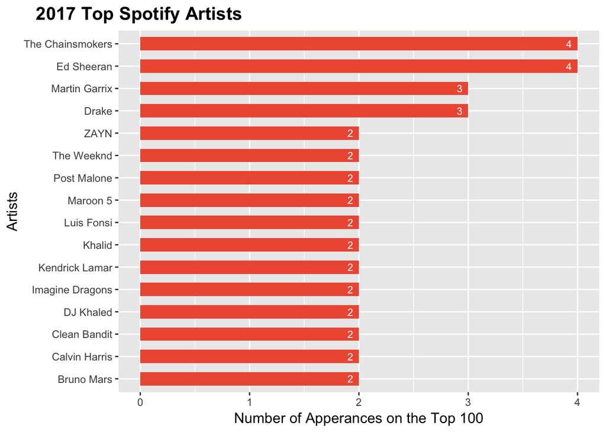

```r
top_artists$artists <- factor(top_artists$artists, levels = top_artists$artists[order(top_artists$number_apperance)]) # visualise the list in descending order

ggplot(top_artists, aes(x = artists, y = number_apperance)) +
    geom_bar(stat = "identity",  fill = "tomato2", width = 0.6 ) +
    labs(title = "2017 Top Spotify Artists", x = "Artists", y = "Number of Apperances on the Top 100") +
    theme(plot.title = element_text(size = 15, hjust = -.3, face = "bold"), axis.title = element_text(size = 12)) +
    geom_text(aes(label=number_apperance), hjust = 2, size = 3, color = 'white') +
    coord_flip()
```

So, It seems like **Ed Sheeran** and **The Chainsmokers** rocked the 2017 with 4 different songs on the Top list, while **Drake** and **Martin Garrix** are following them with 3 different songs.

## Most Popular Songs

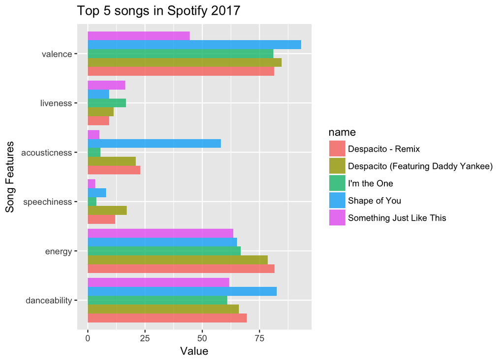

```r
# Top 5 Songs
m5 <- audio_features[c(1:5),]
m5<- m5[, c(2,4,5,9,10,12,13)]
m5<- as.data.frame(m5)
m5.long <- melt(m5, id.vars="name")

ggplot(data = m5.long, aes(x = variable, y = value)) +
  geom_bar(aes(y = value, fill = name), stat = "identity", alpha = 0.8 , position = "dodge") +
  ylab("Value") + xlab("Song Features") +
  coord_flip() + ggtitle("Top 5 songs in Spotify 2017 ")
```

## Correlation between variables

In order to understand the correlation between variables, I’ll use `corrplot` function, which is one of the base data visualization functions.

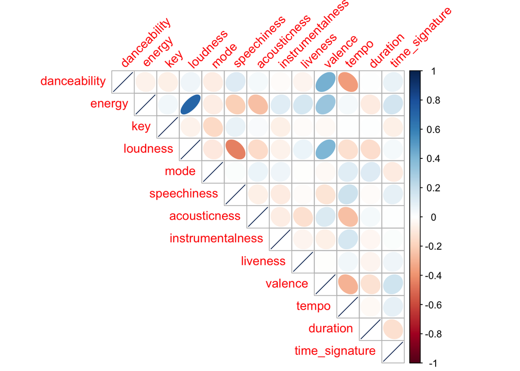

```r
library(corrplot)
audio_features_num <- audio_features[,-(1:3)]
mtCor <- cor(audio_features_num)
corrplot(mtCor, method = "ellipse", type = "upper", tl.srt = 45)
```

- It seems like `energy` and `loudness` are highly positively correlated.
- Also, `valence` is positively correlated with `danceability` and `energy`. Considering happy songs make people energetic and want to dance, the correlation make a lot sense.
- Interestingly, `speechiness` and `loudness` are negatively correlated with each other.